# MA40198: Lab 1: Line-search optimisation methods

## Solution to Question 4

```r
func <- function(theta,y,a,k){

  lin_pred     <- theta[1]+theta[2]*a

  mu           <- k*exp(lin_pred)

  sum_log_dens <- sum(dpois(x = y,
                            lambda = mu,
                            log  = TRUE))
  -sum_log_dens
}

grad <- function(theta,y,a,k){
  lin_pred     <- theta[1]+theta[2]*a
  mu           <- k*exp(lin_pred)

  grad_1 <- sum(mu-y)
  grad_2 <- sum(a*(mu-y))
  c(grad_1,grad_2)
}

hess<-function(theta,y,a,k){
  lin_pred     <- theta[1]+theta[2]*a
  mu           <- k*exp(lin_pred)

  hess_11 <- sum(mu)
  hess_12 <- sum(a*mu)
  hess_22 <- sum(a^2*mu)

  out <- matrix(c(hess_11,hess_12,hess_12,hess_22),
                nrow = 2,
                ncol = 2,
                byrow = TRUE)
  out
}


hess_inv <- function(theta,y,a,k){
  lin_pred     <- theta[1]+theta[2]*a
  mu           <- k*exp(lin_pred)

  det = sum(mu)*sum(a^2*mu)-sum(a*mu)^2

  hess_11 <- sum(a^2*mu)/det
  hess_12 <- -sum(a*mu)/det
  hess_22 <- sum(mu)/det

  out <- matrix(c(hess_11,hess_12,hess_12,hess_22),
                nrow = 2,
                ncol = 2,
                byrow = TRUE)
  out
}






data_male <- dplyr::filter(dat, sex == "male")
data_female <- dplyr::filter(dat, sex == "female")

y_male <- data_male$deaths_COVID
a_male <- data_male$age
k_male <- data_male$population/100000

y_female <- data_female$deaths_COVID
a_female <- data_female$age
k_female <- data_female$population/100000

theta_k = c(-3.0754504, 0.1195576)
tol = 10e-6


euler_func <- function(theta_k, tol, func, grad, hess, hess_inv, y, a, k_in){

    hess_non_pos_def_count <- 0 # the number of times the Hessian is not positive definite
    n_iterations <- 0 # the total number of iterations
    n_backtrackings <- c() # the number of simple backtrackings in each iteration
    k <- 0

    func_old <- func(theta_k, y, a, k_in)
    grad_k <- grad(theta_k, y, a, k_in)
    hess_k <- hess(theta_k, y, a, k_in)
    hess_inv_k <- hess_inv(theta_k, y, a, k_in)


    while (norm(grad_k, type="2") > tol){
        current_n_backtrackings <- 0
        n_iterations <- n_iterations + 1
        dir <- -hess_inv_k%*%grad_k
        alpha_k <- 1
        func_new <- func(theta_k + alpha_k*dir, y, a, k_in)

        if (is.infinite(func_new)){
          func_new = func_old
        }

        while (func_new >= func_old) {
          current_n_backtrackings <- current_n_backtrackings+1
          alpha_k <- alpha_k/2
          func_new <- func(theta_k + alpha_k*dir, y, a, k_in)
          if (is.infinite(func_new)){
            func_new = func_old
          }
        }
        theta_k <- theta_k + alpha_k*dir
        k <- k+1
        func_old <- func(theta_k, y, a, k_in)
        grad_k <- grad(theta_k, y, a, k_in)
        hess_k <- hess(theta_k, y, a, k_in)
        hess_inv_k <- hess_inv(theta_k, y, a, k_in)

        if (!(matrixcalc::is.positive.definite(hess_k))){
          hess_non_pos_def_count <- hess_non_pos_def_count+1
        }
        n_backtrackings[length(n_backtrackings)+1] <- current_n_backtrackings

    }

    c(theta_k, hess_non_pos_def_count, n_iterations, n_backtrackings)
}

output_men <- euler_func(theta_k, tol, func, grad, hess, hess_inv, y_male, a_male, k_male)

output_women <- euler_func(theta_k, tol, func, grad, hess, hess_inv, y_female, a_female, k_female)

theta_hat_men <- c(output_men[1:2])
hess_non_pos_def_count_men <- output_men[3]
n_iterations_men <- output_men[4]
n_backtrackings_men <- output_men[5:length(output_men)]

theta_hat_women <- c(output_women[1:2])
hess_non_pos_def_count_women <- output_women[3]
n_iterations_women <- output_women[4]
n_backtrackings_women <- output_women[5:length(output_men)]

paste("MEN: Theta hat:", theta_hat_men[1], theta_hat_men[2], ",  Number of non positive definite Hessians:", hess_non_pos_def_count_men, ",  Number of Iterations:", n_iterations_men, ",  Number of backtrackings for each iteration:", n_backtrackings_men)
```

```
## [1] "MEN: Theta hat: -2.81751798530377 0.115594025724986 ,  Number of non positive definite Hessians: 0 ,  Number of Iterations: 4 ,  Number of backtrackings for each iteration: 0"
## [2] "MEN: Theta hat: -2.81751798530377 0.115594025724986 ,  Number of non positive definite Hessians: 0 ,  Number of Iterations: 4 ,  Number of backtrackings for each iteration: 0"
## [3] "MEN: Theta hat: -2.81751798530377 0.115594025724986 ,  Number of non positive definite Hessians: 0 ,  Number of Iterations: 4 ,  Number of backtrackings for each iteration: 0"
## [4] "MEN: Theta hat: -2.81751798530377 0.115594025724986 ,  Number of non positive definite Hessians: 0 ,  Number of Iterations: 4 ,  Number of backtrackings for each iteration: 0"
```

```r
## not sure how to not duplicate paste with n_backtrackings_men

paste("WOMEN: Theta hat:", theta_hat_women[1], theta_hat_women[2], ",  Number of non positive definite Hessians:", hess_non_pos_def_count_women, ",  Number of Iterations:", n_iterations_women)
```

```
## [1] "WOMEN: Theta hat: -4.06036160583988 0.124505862862684 ,  Number of non positive definite Hessians: 0 ,  Number of Iterations: 5"
```

```r
euler_func_rel_tol <- function(theta_k, tol, func, grad, hess, hess_inv, y, a, k_in){

    hess_non_pos_def_count <- 0 # the number of times the Hessian is not positive definite
    n_iterations <- 0 # the total number of iterations
    n_backtrackings <- c() # the number of simple backtrackings in each iteration
    k <- 0

    func_old <- func(theta_k, y, a, k_in)
    func_new <- func_old
    grad_k <- grad(theta_k, y, a, k_in)
    hess_k <- hess(theta_k, y, a, k_in)
    hess_inv_k <- hess_inv(theta_k, y, a, k_in)


    while (norm((grad_k*theta_k), type="2") > tol*func_new){
        current_n_backtrackings <- 0
        n_iterations <- n_iterations + 1
        dir <- -hess_inv_k%*%grad_k
        alpha_k <- 1
        func_new <- func(theta_k + alpha_k*dir, y, a, k_in)

        if (is.infinite(func_new)){
          func_new = func_old
        }

        while (func_new >= func_old) {
          current_n_backtrackings <- current_n_backtrackings+1
          alpha_k <- alpha_k/2
          func_new <- func(theta_k + alpha_k*dir, y, a, k_in)
          if (is.infinite(func_new)){
            func_new = func_old
          }
        }
        theta_k <- theta_k + alpha_k*dir
        k <- k+1
        func_old <- func(theta_k, y, a, k_in)
        grad_k <- grad(theta_k, y, a, k_in)
        hess_k <- hess(theta_k, y, a, k_in)
        hess_inv_k <- hess_inv(theta_k, y, a, k_in)

        if (!(matrixcalc::is.positive.definite(hess_k))){
          hess_non_pos_def_count <- hess_non_pos_def_count+1
        }
        n_backtrackings[length(n_backtrackings)+1] <- current_n_backtrackings

    }

    c(theta_k, hess_non_pos_def_count, n_iterations, n_backtrackings)
}


output_men_rel_tol <- euler_func_rel_tol(theta_k, tol, func, grad, hess, hess_inv, y_male, a_male, k_male)

output_women_rel_tol <- euler_func_rel_tol(theta_k, tol, func, grad, hess, hess_inv, y_female, a_female, k_female)

theta_hat_men_rel_tol <- c(output_men_rel_tol[1:2])
hess_non_pos_def_count_men_rel_tol <- output_men_rel_tol[3]
n_iterations_men_rel_tol <- output_men_rel_tol[4]
n_backtrackings_men_rel_tol <- output_men_rel_tol[5:length(output_men_rel_tol)]

theta_hat_women_rel_tol <- c(output_women_rel_tol[1:2])
hess_non_pos_def_count_women_rel_tol <- output_women_rel_tol[3]
n_iterations_women_rel_tol <- output_women_rel_tol[4]
n_backtrackings_women_rel_tol <- output_women_rel_tol[5:length(output_men)]

paste("Relative Tolerance... MEN: Theta hat:", theta_hat_men_rel_tol[1], theta_hat_men_rel_tol[2], ",  Number of non positive definite Hessians:", hess_non_pos_def_count_men_rel_tol, ",  Number of Iterations:", n_iterations_men_rel_tol, ",  Number of backtrackings for each iteration:", n_backtrackings_men_rel_tol)
```

```
## [1] "Relative Tolerance... MEN: Theta hat: -2.81751798533228 0.11559402572547 ,  Number of non positive definite Hessians: 0 ,  Number of Iterations: 3 ,  Number of backtrackings for each iteration: 0"
## [2] "Relative Tolerance... MEN: Theta hat: -2.81751798533228 0.11559402572547 ,  Number of non positive definite Hessians: 0 ,  Number of Iterations: 3 ,  Number of backtrackings for each iteration: 0"
## [3] "Relative Tolerance... MEN: Theta hat: -2.81751798533228 0.11559402572547 ,  Number of non positive definite Hessians: 0 ,  Number of Iterations: 3 ,  Number of backtrackings for each iteration: 0"
```

```r
## not sure how to not duplicate paste with n_backtrackings_men

paste("Relative Tolerance... WOMEN: Theta hat:", theta_hat_women_rel_tol[1], theta_hat_women_rel_tol[2], ",  Number of non positive definite Hessians:", hess_non_pos_def_count_women_rel_tol, ",  Number of Iterations:", n_iterations_women_rel_tol)
```

```
## [1] "Relative Tolerance... WOMEN: Theta hat: -4.06036157846053 0.124505862555505 ,  Number of non positive definite Hessians: 0 ,  Number of Iterations: 4"
```

## Question 5

In the scatterplot from Question 2, for both men and women, add the log of the fitted mean curve which is given by:
$$\log
\exp(\hat{\theta_1}+\hat{\theta}_2\,a)=\hat{\theta_1}+\hat{\theta}_2\,a$$
so is a straight line. Comment on the fit of this line to the data points in each sex group.

## Solution to Question 5

```r
theta_1_hat_men <- theta_hat_men[1]
theta_2_hat_men <- theta_hat_men[2]
theta_1_hat_women <- theta_hat_women[1]
theta_2_hat_women <- theta_hat_women[2]

func_men <- function(a){
  theta_1_hat_men+theta_2_hat_men*a
}

func_women <- function(a){
  theta_1_hat_women+theta_2_hat_women*a
}

dat$rate<-dat$deaths_COVID/(dat$population/100000) # Add new variable
par(mfrow=c(1,2))
x_range <- seq(min(dat$age), max(dat$age), length.out = 1000)

plot(dat$age[1:17],log(dat$rate[1:17]),xlab='Age',ylab='log(Death rate)',main='Male')
lines(x_range, func_men(x_range))

plot(dat$age[18:34],log(dat$rate[18:34]),xlab='Age',ylab='log(Death rate)',main='Female')
lines(x_range, func_women(x_range))
```

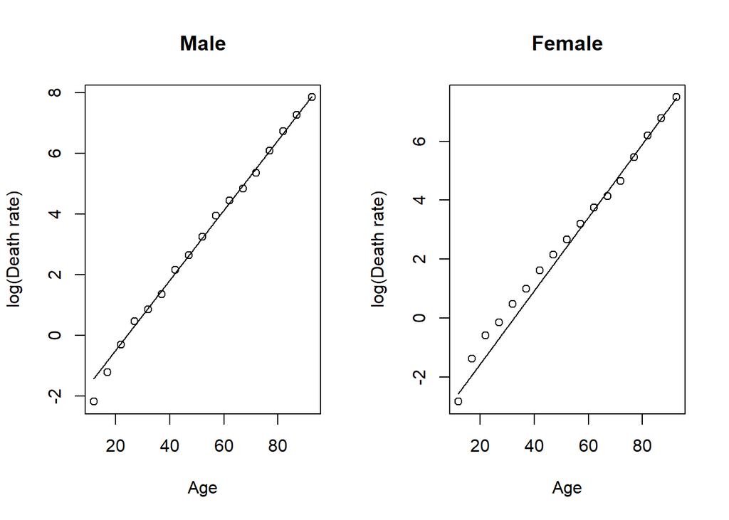

[figure not shown]

## Question 6

In the previous question we have considered men and women separately . Consider now the following model that integrates the effect of sex:

$$\mbox{death rate per
100k}=\exp(\theta_1+\theta_2\, age+\theta_3\,\delta_{male})$$
where $\delta_{male}=1$ if male and $\delta_{male}=0$ if female.

Using Newton’s algorithm:

- Find a simple starting value $\boldsymbol{\theta}_0$ using the linear form of the model (e.g. use least squares)
- Find the maximum likelihood estimator of the unknown parameter $\boldsymbol{\theta}^T=(\theta_1,\theta_2,\theta_3)$